# 삼성DS과정 파이썬 실습

# 2장. 표본분포

## review...

1) 중신극한정리 : 표본의 크기 n이 충분히 클 때에는, 임의의 모집단으로부터의 표본평균 $\bar{X}$의 분포가 모집단의 분포와는 관계없이 근사적으로 정규분포 $N(\mu,\frac{\sigma^2}{n})$을 따른다.

- 이항분포의 정규근사 : 이항분포의 경우 n의 값이 커지면 계산이 힘들다. $X_1,X_2,\dots,X_n$이 성공률이 p인 베르누이 분포를 따르는 무한모집단의 랜덤표본일 때, $S=\sum_{i=1}^{n}X_i$는 이항분포 $B(n,p)$를 따르고, 모평균은 np, 모분산은 np(1-p)임을 알고 있다. 이 때 중심극한정리를 적용하면, n이 클때 다음과 같은 식이 만족한다.

$$\frac{S-np}{\sqrt{np(1-p)}}=\frac{\hat{p}-p}{\sqrt{p(1-p)/n}}\sim N(0,1)$$

2) 카이제곱분포 : $\sum_{i=1}^{k}Z_i^2\sim \chi^2(k)$

- 확률변수 $Z_1,Z_2,\dots,Z_k$ 이 정규분포 $N(0,1)$로부터 추출한 k개의 랜덤표본일 때, $V=Z_1^2+Z_2^2\dots+Z_k^2$ 의 분포를 자유도 k인 카이제곱분포라고 한다.
- 정규분포 $N(\mu,\sigma^2)$로부터 추출한 n개의 랜덤표본 $X_1,X_2,\dots,X_n$ 의 표본분산 $S^2=\frac{1}{n-1}\sum_{i=1}^{n}(X_i-\bar{X})^2$ 에 대해 다음이 성립한다.

$$\frac{(n-1)S^2}{\sigma^2} \sim \chi^2(n-1)$$

3) t분포 : $T \sim t(k)$

- 표준정규분포를 따르는 확률변수를 Z라 하고, 이와는 독립이며 자유도가 k인 카이제곱분포를 따르는 확률변수를 V라고 할 때, $T=\frac{Z}{\sqrt{V/k}}$ 의 분포를 자유도가 k인 t분포라고 한다.
- $X_1,X_2,\dots,X_k$ 이 정규분포 $N(\mu,\sigma^2)$를 따르는 정규모집단에서 추출한 랜덤표본일 때, 스튜던트화된 표본평균의 분포가 다음과 같다.

$$\frac{\bar{X}-\mu}{S/\sqrt{n}} \sim t(n-1)$$

4) F분포 : $F \sim F(k_1,k_2)$

- F분포는 두 정규모집단의 분산을 비교할 때 분산의 비에 대한 추론에 이용되는 분포이다.
- 두 확률변수 $V_1,V_2$ 가 서로 독립이고 각각 자유도가 $k_1,k_2$인 카이제곱 분포를 따를 때, $F=\frac{V_1/k_1}{V_2/k_2}$ 의 분포를 자유도가 $(k_1,k_2)$인 F분포라고 한다.
- 서로 독립인 두 정규모집단 $N(\mu_1,\sigma_1^2)$, $N(\mu_2,\sigma_2^2)$에서 추출한 랜덤표본 $X_1,X_2,\dots,X_{n_1}$, $Y_1,Y_2,\dots,Y_{n_2}$, 그리고 각각의 표본분산 $S_1^2,S_2^2$ 에 대해 다음과 같은 식이 성립한다.

$$\frac{\sigma_2^2}{\sigma_1^2}.\frac{S_1^2}{S_2^2} \sim F(n_1-1,n_2-1)$$

- 확률변수 F가 자유도가 $(k_1,k_2)$인 F분포를 따를 때, $\frac{1}{F} \sim F(k_2,k_1)$ 가 성립한다.

```python
## 이항분포의 정규근사 그래프 그리기

def showplot():
    plt.subplot(131)
    # subplot : plot 창을 나누는 역할, 131 : 1행 3열의 첫번째
    plt.xlim(-3,15)
    # xlim : 표시되는 x좌표의 범위
    plt.plot(range(11),binom.pmf(range(11),n=10,p=0.1),marker='o')
    plt.plot(range(-3,15),norm.pdf(range(-3,15),loc=1,scale=np.sqrt(0.9)),color='black')
    plt.subplot(132)
    # 1행 3열의 2번째
    plt.xlim(-3,15)
    plt.plot(range(16),binom.pmf(range(16),n=30,p=0.1),marker='o')
    plt.plot(range(-3,15),norm.pdf(range(-3,15),loc=3,scale=np.sqrt(2.7)),color='black')
    plt.subplot(133)
    # 1행 3열의 3번째
    plt.xlim(-3,15)
    plt.plot(range(26),binom.pmf(range(26),n=50,p=0.1),marker='o')
    plt.plot(range(-3,15),norm.pdf(range(-3,15),loc=5,scale=np.sqrt(4.5)),color='black')
```

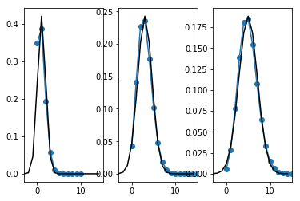

```python
showplot()
#slide 하나에 그림을 표시하기 위해 showplot 함수를 따로 정의하였다.
```

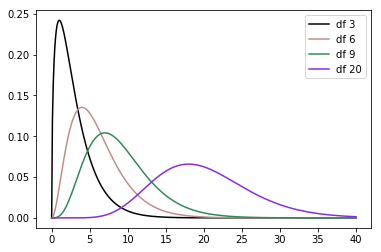

```python
## 카이제곱분포의 pdf 그리기
# from scipy.stats import chi2 코드를 이용하여 카이제곱분포 함수들을 불러온다.

from scipy.stats import chi2

x=np.arange(0,40.1,0.1)

plt.plot(x,chi2.pdf(x,3), color='black', label='df 3')
plt.plot(x,chi2.pdf(x,6),color='rosybrown', label='df 6')
plt.plot(x,chi2.pdf(x,9),color='seagreen', label='df 9')
plt.plot(x,chi2.pdf(x,20),color='blueviolet', label='df 20')

plt.legend(loc='upper right')
#우측 상단에 범례
# plt.plot의 label 옵션을 통해 범례에 사용할 선의 이름을 지정할 수 있다.
```

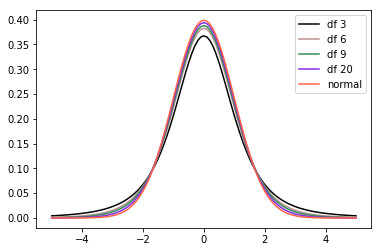

```python
## t분포의 pdf 그리기
# from scipy.stats import t 코드를 이용하여 t분포 함수들을 불러온다.

from scipy.stats import t

x=np.arange(-5,5.1,0.1)

plt.plot(x,t.pdf(x,3), color='black', label='df 3')
plt.plot(x,t.pdf(x,6),color='rosybrown', label='df 6')
plt.plot(x,t.pdf(x,9),color='seagreen', label='df 9')
plt.plot(x,t.pdf(x,20),color='blueviolet', label='df 20')
plt.plot(x,norm.pdf(x,0,1),color='tomato', label='normal')

plt.legend(loc='upper right')
# 우측 상단에 범례
#plt.plot의 label 옵션을 통해 범례에 사용할 선의 이름을 지정할 수 있다.
```

```python
## F분포의 pdf 그리기
# from scipy.stats import f 코드를 이용하여 F분포 함수들을 불러온다.

from scipy.stats import f

def showplot1():
    x=np.arange(0.001,4.1,0.1)
    #시작점을 0으로 설정하면 에러가 뜨기 때문에 0.001로 설정한다. log(0)term 때문에 생기는 오류로 자세히 다루지는 않는다.

    plt.subplot(131)
    plt.plot(x,f.pdf(x,3,20), color='seagreen',label='k2=20')
    plt.plot(x,f.pdf(x,3,10), color='blueviolet',label='k2=10')
    plt.plot(x,f.pdf(x,3,6), color='coral',label='k2=6')
    plt.plot(x,f.pdf(x,3,3), color='black',label='k2=3')
    plt.title('f dist w.r.t. k1=3')
    plt.legend(loc='upper right')

    plt.subplot(132)
    plt.plot(x,f.pdf(x,10,20), color='seagreen',label='k2=20')
    plt.plot(x,f.pdf(x,10,10), color='blueviolet',label='k2=10')
    plt.plot(x,f.pdf(x,10,6), color='coral',label='k2=6')
    plt.plot(x,f.pdf(x,10,3), color='black',label='k2=3')
    plt.title('f dist w.r.t. k1=10')
    plt.legend(loc='upper right')

    plt.subplot(133)
    plt.plot(x,f.pdf(x,20,20), color='seagreen',label='k2=20')
    plt.plot(x,f.pdf(x,20,10), color='blueviolet',label='k2=10')
    plt.plot(x,f.pdf(x,20,6), color='coral',label='k2=6')
    plt.plot(x,f.pdf(x,20,3), color='black',label='k2=3')
    plt.title('f dist w.r.t. k1=20')
    plt.legend(loc='upper right')
```

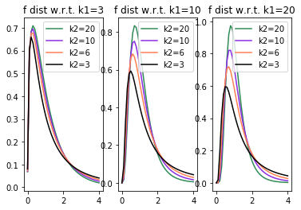

```python
showplot1()
```

# 3장. 통계적 추론

## review...

1) 점추정

- 적률 추정법 : 모집단의 적률 $m_r=E(X^r)$에 대한 추정을 할 때 사용되는 표본적률은 $\hat{m_r}=\frac{1}{n}(X_1^r+\dots +X_n^r)$ 이다.
- 최대가능도 추정법 : 모수의 가능도를 최대가 되게 하는 값으로, $\theta$ 의 최대가능도추정량은 $\hat{\theta}=\arg \max_{\theta \in \Omega}L(\theta|X_1,\dots , X_n)$ 이다.

2) 구간추정

- 신뢰수준(confidence level)이 $100(1-\alpha)\%$인 신뢰구간 (L,U)는 다음과 같다.

$$P(L\leq \theta \leq U)=1-\alpha$$

- $\mu$ 의 $100(1-\alpha)\%$ 신뢰구간은 다음과 같다.

$$(\bar{X}-Z_{\frac{\alpha}{2}}\frac{\sigma}{\sqrt{n}},\bar{X}+Z_{\frac{\alpha}{2}}\frac{\sigma}{\sqrt{n}})$$

- $Z_{\frac{\alpha}{2}}\frac{\alpha}{\sqrt{n}}\leq d$ 이므로, 오차의 한계를 d이하로 하는 표본크기 n은 다음과 같다.

$$(\frac{Z_{\frac{\alpha}{2}}\sigma}{d})^2 \leq n$$

(1) 중앙아메리카의 저소득층 원주민을 대상으로 49명의 표본조사를 한 결과 혈청 내의 콜레스테롤 양이 평균 157.02(mg/L) 이었다고 한다. 이들 원주민 전체에서 혈청 내의 콜레스트롤 양이 정규분포이고, 표준편차가 30(mg/L)라고 할 때, 원주민 전체에서 혈청 내의 콜레스테롤 양의 평균에 대하여 95% 신뢰구간을 구해보자.

(2) 모평균에 대한 95% 추정의 오차 한계를 5(mg/L) 이하로 하기를 원한다면, 몇 명 이상의 원주민을 표본으로 조사해야 하는가?

```python
# (1)
n = 49; sigma=30 ; xbar = 157.02 ; alpha=0.05 ; d=5

z_alpha=norm.ppf(1-alpha/2)
# Z_{0.025}

c_i=np.array([round(xbar-z_alpha*sigma/np.sqrt(n),3),round(xbar+z_alpha*sigma/np.sqrt(n),3)])
# 참고: round함수는 array를 바로 반올림 하지 않는다.
print(c_i)
```

```
[148.62 165.42]
```

```python
# (2)

min_n = (z_alpha*sigma/d)**2
# 정수가 아닌 수를 제곱할 때는 ^ 대신 ** 사용

print(np.ceil(min_n))
#ceil: 올림
```

```
139.0
```

예제1)

(1) 많은 심장병 환자들은 자신의 심장 박동을 제어하기 위해서 심장박동조절기를 이식한다. 플라스틱 컨넥터 모듈은 조절기의 맨 위쪽에 있다. 표준편차가 0.0015라 하고 대략적으로 정규분포를 따른다. 75개의 무선 표본을 조사한 결과 평균 깊이가 0.310이라고 한다. 어떤 제조업체에서 만든 모든 컨넥터 모듈 깊이의 평균의 95% 신뢰구간을 찾으시오.

(2) 위 문제에서 실제 모평균에 대한 95% 추정의 오차 한계를 0.0005 이하로 하기를 원한다면, 필요한 표본 크기는?

# 4장. 모평균과 모분산에 관한 추론

## review...

1) 모평균에 관한 유의성 검정(모분산을 아는 경우)

- 가설 $H_0 : \mu=\mu_0$
- 검정통계량 $Z=\frac{\bar{X}-\mu_0}{\sigma/\sqrt{n}} \sim N(0,1)$ under $H_0$, 관측값=$z_0$

| $H_1$ | 유의확률 | 기각역 |
| --- | --- | --- |
| $\mu>\mu_0$ | $P=P(Z>z_0)$ | $Z> z_\alpha$ |
| $\mu<\mu_0$ | $P=P(Z<z_0)$ | $Z< -z_\alpha$ |
| $\mu\neq \mu_0$ | $P=P(\lvert Z\rvert>\vert z_0\vert)$ | $\lvert Z \rvert> z_{\alpha/2}$ |

2) 모평균에 관한 유의성 검정(모분산을 모르는 경우)

- 가설 $H_0 : \mu=\mu_0$
- 검정통계량 $T=\frac{\bar{X}-\mu_0}{S/\sqrt{n}}\sim t(n-1)$ under $H_0$, 관측값=$t_0$

| $H_1$ | 유의확률 | 기각역 |
| --- | --- | --- |
| $\mu>\mu_0$ | $P=P(T>t_0)$ | $T> t_\alpha(n-1)$ |
| $\mu<\mu_0$ | $P=P(T<t_0)$ | $T< -t_\alpha(n-1)$ |
| $\mu\neq \mu_0$ | $P=P(\lvert T \rvert>\lvert t_0 \rvert)$ | $\lvert T\rvert> t_{\alpha/2}(n-1)$ |

3) 대응비교에 의한 모평균 비교

- 가설 $H_0 : \mu_1-\mu_2=\delta_0$
- 검정통계량 $T=\frac{\bar{D}-\delta_0}{S_d/\sqrt{n}}\sim t(n-1)$ under $H_0$, 관측값=$t_0$

| $H_1$ | 유의확률 | 기각역 |
| --- | --- | --- |
| $\mu_1-\mu_2>\delta_0$ | $P=P(T>t_0)$ | $T> t_\alpha(n-1)$ |
| $\mu_1-\mu_2<\delta_0$ | $P=P(T<t_0)$ | $T< -t_\alpha(n-1)$ |
| $\mu_1-\mu_2\neq \delta_0$ | $P=P(\lvert T\rvert>\lvert t_0 \rvert)$ | $\lvert T\rvert> t_{\alpha/2}(n-1)$ |

4) 독립 이표본에 의한 모평균 비교(모분산을 아는 경우)

- 가설 $H_0 : \mu_1=\mu_2$
- 검정통계량 $Z=\frac{(\bar{X_1}-\bar{X_2})-(\mu_1-\mu_2)}{\sqrt{\frac{\sigma_1^2}{n_1}+\frac{\sigma_2^2}{n_2}}} \sim N(0,1)$ under $H_0$, 관측값=$z_0$

| $H_1$ | 유의확률 | 기각역 |
| --- | --- | --- |
| $\mu_1>\mu_2$ | $P=P(Z>z_0)$ | $Z> z_\alpha$ |
| $\mu_1<\mu_2$ | $P=P(Z<z_0)$ | $Z< -z_\alpha$ |
| $\mu_1\neq \mu_2$ | $P=P(\lvert Z\rvert>\vert z_0\vert)$ | $\lvert Z\rvert> z_{\alpha/2}$ |

5) 독립 이표본에 의한 모평균 비교(모분산을 모르는 경우(등분산가정))

- 가설 $H_0 : \mu_1-\mu_2=\delta_0$
- 합동표본분산 ${S_p}^2=\frac{(n_1-1){S_1}^2+(n_2-1){S_2}^2}{n_1+n_2-2}$
- 검정통계량 $T=\frac{(\bar{x_1}-\bar{x_2})-\delta_0}{S_p \sqrt{\frac{1}{n_1}+\frac{1}{n_2}}}\sim t(n_1+n_2-2)$ under $H_0$, 관측값=$t_0$

| $H_1$ | 유의확률 | 기각역 |
| --- | --- | --- |
| $\mu_1-\mu_2>\delta_0$ | $P=P(T>t_0)$ | $T> t_\alpha(n_1+n_2-2)$ |
| $\mu_1-\mu_2<\delta_0$ | $P=P(T<t_0)$ | $T< -t_\alpha(n_1+n_2-2)$ |
| $\mu_1-\mu_2\neq \delta_0$ | $P=P(\lvert T\rvert>\vert t_0\vert)$ | $\vert T\vert> t_{\alpha/2}(n_1+n_2-2)$ |

6) 독립 이표본에 의한 모평균 비교(모분산을 모르는 경우(이분산가정))

- 가설 $H_0 : \mu_1-\mu_2=\delta_0$
- 검정통계량 $T=\frac{(\bar{x_1}-\bar{x_2})-\delta_0}{\sqrt{\frac{{S_1}^2}{n_1}+\frac{{S_2}^2}{n_2}}}\sim t(df^*)$ under $H_0$, 관측값=t_0
- $df^*=\frac{({S_1}^2/n_1+{S_2}^2/n_2)^2}{\frac{1}{n_1-1}({S_1}^2/n_1)^2+\frac{1}{n_2-1}({S_2}^2/n_2)^2}$

| $H_1$ | 유의확률 | 기각역 |
| --- | --- | --- |
| $\mu_1-\mu_2>\delta_0$ | $P=P(T>t_0)$ | $T> t_\alpha(df^*)$ |
| $\mu_1-\mu_2<\delta_0$ | $P=P(T<t_0)$ | $T< -t_\alpha(df^*)$ |
| $\mu_1-\mu_2\neq \delta_0$ | $P=P(\vert T\vert>\vert t_0\vert)$ | $\vert T\vert> t_{\alpha/2}(df^*)$ |

7) 모분산에 관한 유의성 검정

- 가설 $H_0 : \sigma^2=\sigma_0^2$
- 검정통계량 $\chi^2=\frac{(n-1)S^2}{{\sigma}^2}\sim \chi^2(n-1)$ under $H_0$, 관측값=$\chi_0^2$

| $H_1$ | 유의확률 | 기각역 |
| --- | --- | --- |
| $ \sigma^2>\sigma_0^2$ | $P=P(\chi^2>\chi_0^2)$ | $\chi^2> \chi_\alpha^2(n-1)$ |
| $ \sigma^2<\sigma_0^2$ | $P=P(\chi^2<\chi_0^2)$ | $\chi^2< \chi_{1-\alpha}^2(n-1)$ |
| $ \sigma^2\neq \sigma_0^2$ | $P=2P(\chi^2>\chi_0^2)$ or $P=2P(\chi^2<\chi_0^2)$ | $\chi^2> \chi_{\alpha/2}^2(n-1)$ or $\chi^2< \chi_{1-\alpha/2}^2(n-1)$ |

8) 두 모집단의 분산비에 관한 유의성 검정

- 가설 $H_0 : \sigma_1^2=\sigma_2^2$
- 검정통계량 $F=\frac{S_1^2/\sigma_1^2}{S_2^2/\sigma_2^2}\sim F(n_1-1,n_2-1)$ under $H_0$, 관측값=f

| $H_1$ | 유의확률 | 기각역 |
| --- | --- | --- |
| $ \sigma_1^2>\sigma_2^2$ | $P=P(F>f_0)$ | $F> F_\alpha(n_1-1,n_2-1)$ |
| $ \sigma_1^2<\sigma_2^2$ | $P=P(F<f_0)$ | $F< F_{1-\alpha}(n_1-1,n_2-1)$ |
| $ \sigma_1^2\neq \sigma_2^2$ | $P=2P(F>f_0)$ or $P=2P(F<f_0)$ | $F> F_{\alpha/2}(n_1-1,n_2-1)$ or $F< F_{1-\alpha/2}(n_1-1,n_2-1)$ |

```python
## n=64, 표본평균=27.75, 표본표준편차=5.083 인 표본을 토대로 모평균의 99% 신뢰구간을 추정해보도록 하자.

n = 64; sigma=5.083 ; xbar = 27.75 ; alpha=0.01

t_alpha=t.ppf(1-alpha/2, n-1)
# t_{0.025}
print(round(t_alpha,3))

c_i=np.array([round(xbar-t_alpha*sigma/np.sqrt(n),3),round(xbar+t_alpha*sigma/np.sqrt(n),3)])
print(c_i)
```

```
2.656
[26.062 29.438]
```

예제2) 서울시 중학교 3학년 남학생의 체중 평균값을 구하기 위해 학생 9명을 무작위로 추출하여 체중을 측정해서 얻은 수치는 다음과 같다고 한다.

53.0, 51.5, 47.0, 54.5, 44.0, 53.0, 45.5, 56.0, 45.5

(1) 이 표본을 토대로 모평균의 95% 신뢰구간을 추정해보아라.

(2) 만약 모분산이 16으로 알려져 있을 경우, 95% 신뢰구간을 추정해보아라.